# 2020_10_20_tidy_tuesday.R

So I start by importing the data using the code provided by TidyTuesday.

```r
# Get the Data
# Read in with tidytuesdayR package

tuesdata <- tidytuesdayR::tt_load('2020-10-20')
```

```
## --- Compiling #TidyTuesday Information for 2020-10-20 ----
```

```
## --- There is 1 file available ---
```

```
## --- Starting Download ---
```

```
## --- Download complete ---
```

```r
beer_awards <- tuesdata$beer_awards
beer_awards
```

```
## # A tibble: 4,970 x 7
##    medal  beer_name               brewery      city    state category       year
##    <chr>  <chr>                   <chr>        <chr>   <chr> <chr>         <dbl>
##  1 Gold   Volksbier Vienna        Wibby Brewi~ Longmo~ CO    American Amb~  2020
##  2 Silver Oktoberfest             Founders Br~ Grand ~ MI    American Amb~  2020
##  3 Bronze Amber Lager             Skipping Ro~ Staunt~ VA    American Amb~  2020
##  4 Gold   Lager at World's End    Epidemic Al~ Concord CA    American Lag~  2020
##  5 Silver Seismic Tremor          Seismic Bre~ Santa ~ CA    American Lag~  2020
##  6 Bronze Lite Thinking           Pollyanna B~ Lemont  IL    American Lag~  2020
##  7 Gold   Beachscape              Ventura Coa~ Ventura CA    American Pil~  2020
##  8 Silver Imagine a World with B~ Freetail Br~ San An~ TX    American Pil~  2020
##  9 Bronze Pilsner                 Old Town Br~ Portla~ OR    American Pil~  2020
## 10 Gold   Tank 7                  Boulevard B~ Kansas~ MO    American-Bel~  2020
## # ... with 4,960 more rows
```

I then check the range of year covered by the dataset.

```r
beer_awards %>%
  summarise(year_min = min(year),
            year_max = max(year)
            )
```

```
## # A tibble: 1 x 2
##   year_min year_max
##      <dbl>    <dbl>
## 1     1987     2020
```

Quickly looking to see if, and how NA values are used in the dataset. There aren’t any NAs.

```r
beer_awards %>%
  map(~ sum(is.na(.)))
```

```
## $medal
## [1] 0
##
## $beer_name
## [1] 0
##
## $brewery
## [1] 0
##
## $city
## [1] 0
##
## $state
## [1] 0
##
## $category
## [1] 0
##
## $year
## [1] 0
```

I decided to take a look at the medals won by state.

```r
state_wins <- beer_awards %>%
  group_by(state) %>%
  summarise(wins = n()) %>%
  mutate(prop_wins = wins / sum(wins)) %>%

  ungroup()
state_wins
```

```
## # A tibble: 52 x 3
##    state  wins prop_wins
##    <chr> <int>     <dbl>
##  1 Ak        1  0.000201
##  2 AK       62  0.0125
##  3 AL        6  0.00121
##  4 AR        5  0.00101
##  5 AZ       92  0.0185
##  6 CA      962  0.194
##  7 CO      659  0.133
##  8 CT       16  0.00322
##  9 DC        4  0.000805
## 10 DE       43  0.00865
## # ... with 42 more rows
```

Then visualizing the distribution of number of medals won by each state (over the period 1987 - 2020). The paired histogram and box plot, show a couple of interesting outliers (i.e. state that have won very large numbers of medals)

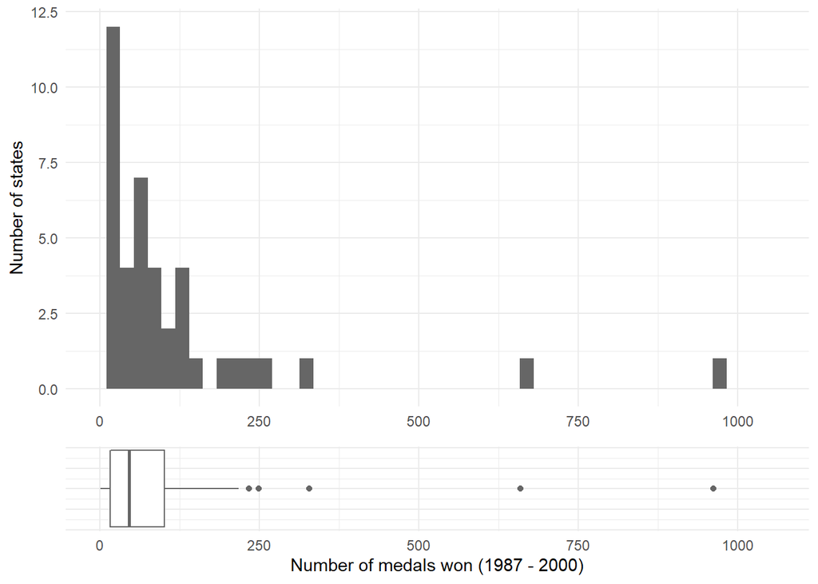

```r
format_hist_box_pair_plot <- function(x_lims){
  list(scale_x_continuous(limits= x_lims),
       theme_minimal()
  )
}

hist_box_pair_plot <- function(df, x_var, x_lims = c(0, 1000), x_label, y_label,
                               colour = "grey40", ...){

  histogram <- ggplot(data = df,
                      mapping = aes_string(x = x_var))

  histogram <- histogram + geom_histogram(fill = colour, bins = 50) +

    labs(x = NULL, y = y_label) +
    format_hist_box_pair_plot(x_lims)

  box_plot <- ggplot(data = df,
                     mapping = aes_string(x = x_var))

  box_plot <- box_plot + geom_boxplot(colour = colour) +

    scale_y_continuous(labels = NULL) +
    labs(x = x_label) +
    format_hist_box_pair_plot(x_lims)

  #combine and align the histogram and box plot
  cowplot::plot_grid(histogram, box_plot,
                     ncol = 1, rel_heights = c(3, 1),
                     align = 'v', axis = 'lr')
}

n_max <- max(state_wins$wins) * 1.1

hist_box_pair_plot(df = state_wins, x_var = "wins", x_lims = c(0, n_max), x_label = "Number of medals won (1987 - 2000)", y_label = "Number of states")
```

Sorting the `state_wins` dataframe shows that California has the most wins.

```r
state_wins %>%
  arrange(desc(wins))
```

```
## # A tibble: 52 x 3
##    state  wins prop_wins
##    <chr> <int>     <dbl>
##  1 CA      962    0.194
##  2 CO      659    0.133
##  3 OR      328    0.0660
##  4 TX      249    0.0501
##  5 WI      234    0.0471
##  6 PA      218    0.0439
##  7 WA      200    0.0402
##  8 IL      155    0.0312
##  9 VA      138    0.0278
## 10 MO      130    0.0262
## # ... with 42 more rows
```

So, I decided to take a look at the data for California in more detail.

```r
CA_awards <- beer_awards %>%
  filter(state == "CA")

CA_awards
```

```
## # A tibble: 962 x 7
##    medal  beer_name    brewery            city    state category            year
##    <chr>  <chr>        <chr>              <chr>   <chr> <chr>              <dbl>
##  1 Gold   Lager at Wo~ Epidemic Ales      Concord CA    American Lager      2020
##  2 Silver Seismic Tre~ Seismic Brewing C~ Santa ~ CA    American Lager      2020
##  3 Gold   Beachscape   Ventura Coast Bre~ Ventura CA    American Pilsener   2020
##  4 Gold   Wookey Jack  Firestone Walker ~ Marina~ CA    American-Style Bl~  2020
##  5 Bronze All-America~ Auburn Alehouse    Auburn  CA    American-Style Br~  2020
##  6 Silver Somewhere G~ Institution Ale C~ Camari~ CA    American-Style Pa~  2020
##  7 Gold   Vice Sans F~ Wild Barrel Brewi~ San Ma~ CA    American-Style So~  2020
##  8 Bronze Mai Tai P.A. Alvarado Street B~ Salinas CA    American-Style St~  2020
##  9 Gold   Funk Yeah    Beachwood Blendery Long B~ CA    Belgian-Style Lam~  2020
## 10 Gold   Tangible Pa~ Riip Beer Co.      Huntin~ CA    Belgian-Style Spe~  2020
## # ... with 952 more rows
```

Looking at the distribution of medals wins at the next level down of granularity (the city).

```r
CA_city_wins <- CA_awards %>%
  group_by(city) %>%
  summarise(wins = n()) %>%
  ungroup() %>%
  mutate(log_wins = log10(wins))
CA_city_wins
```

```
## # A tibble: 149 x 3
##    city               wins log_wins
##    <chr>             <int>    <dbl>
##  1 (Brea, CA) Brea       1    0
##  2 (Corona, CA) Brea     2    0.301
##  3 Alameda               1    0
##  4 Alpine                3    0.477
##  5 Anaheim              10    1
##  6 Antioch               9    0.954
##  7 Arcata                7    0.845
##  8 Arroyo Grande         2    0.301
##  9 Atascadero            1    0
## 10 Auburn               16    1.20
## # ... with 139 more rows
```

Plotting the distribution of meal wins by city produces a paired boxplot-histogram a distribution that looks very similar to the plot of state wins.

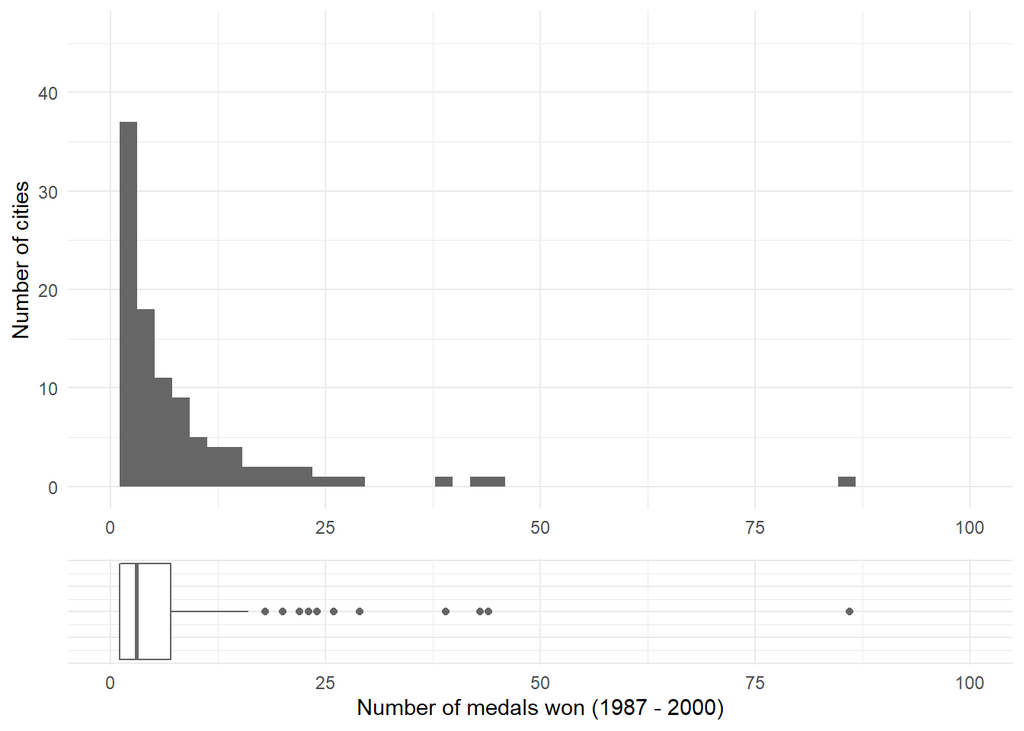

```r
hist_box_pair_plot(df = CA_city_wins, x_var = "wins", x_lims = c(0, 100), x_label = "Number of medals won (1987 - 2000)", y_label = "Number of cities")
```

Given the heavy right skew of the distribution, I thought it was worth plotting on a log axis. Although this didn’t add any particular insight.

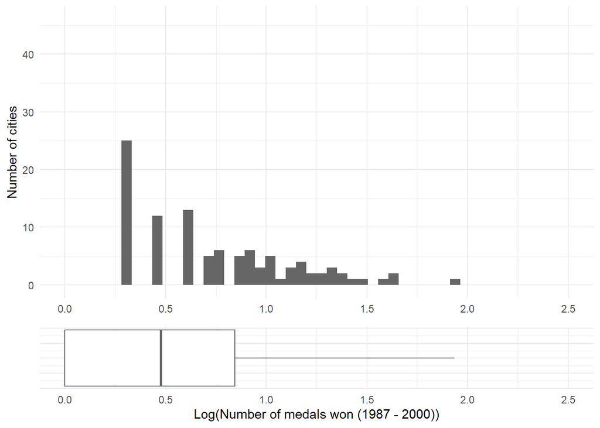

```r
hist_box_pair_plot(df = CA_city_wins, x_var = "log_wins", x_lims = c(0, 2.5), x_label = "Log(Number of medals won (1987 - 2000))", y_label = "Number of cities")
```

The interesting outlier on the right of the plot with 86 wins is San Diego.

```r
CA_city_wins %>%
  arrange(desc(wins))
```

```
## # A tibble: 149 x 3
##    city           wins log_wins
##    <chr>         <int>    <dbl>
##  1 San Diego        86     1.93
##  2 Carlsbad         44     1.64
##  3 Paso Robles      43     1.63
##  4 San Francisco    39     1.59
##  5 Santa Rosa       29     1.46
##  6 Larkspur         26     1.41
##  7 Santa Cruz       24     1.38
##  8 Solana Beach     23     1.36
##  9 San Marcos       22     1.34
## 10 Chico            20     1.30
## # ... with 139 more rows
```

So, I thought it would be interesting to conclude this quick EDA by looking at the how the number of medals won over time had varied for the most successful state (California) and the most successful city within that state (San Diego)

```r
SD_awards <- beer_awards %>%
  filter (city == "San Diego")

SD_awards
```

```
## # A tibble: 86 x 7
##    medal  beer_name        brewery        city   state category             year
##    <chr>  <chr>            <chr>          <chr>  <chr> <chr>               <dbl>
##  1 Bronze Hell Camino Bel~ Dos Desperado~ San D~ CA    Belgian-Style Stro~  2020
##  2 Bronze Tres Tres        Ocean Beach B~ San D~ CA    Bohemian-Style Pil~  2020
##  3 Gold   Tabula Rasa      Second Chance~ San D~ CA    Robust Porter        2020
##  4 Silver Guillaume        Pizza Port Oc~ San D~ CA    Session Beer or No~  2020
##  5 Silver Bowie Knife      Thunderhawk A~ San D~ CA    American-Style Bla~  2019
##  6 Gold   Sea SeC3=B1or! ~ SouthNorte Be~ San D~ CA    American-Style Cre~  2019
##  7 Bronze Industrial Gris  Resident Brew~ San D~ CA    Belgian- and Frenc~  2019
##  8 Bronze OB Bubble Dubbel Kilowatt Brew~ San D~ CA    Belgian-Style Dubb~  2019
##  9 Silver Citra Pils       Saint Archer ~ San D~ CA    Contemporary Ameri~  2019
## 10 Gold   Enough Said N/A  Two Roots Bre~ San D~ CA    Non-Alcohol Beer o~  2019
## # ... with 76 more rows
```

Plotting the medals won by breweries in California over time.

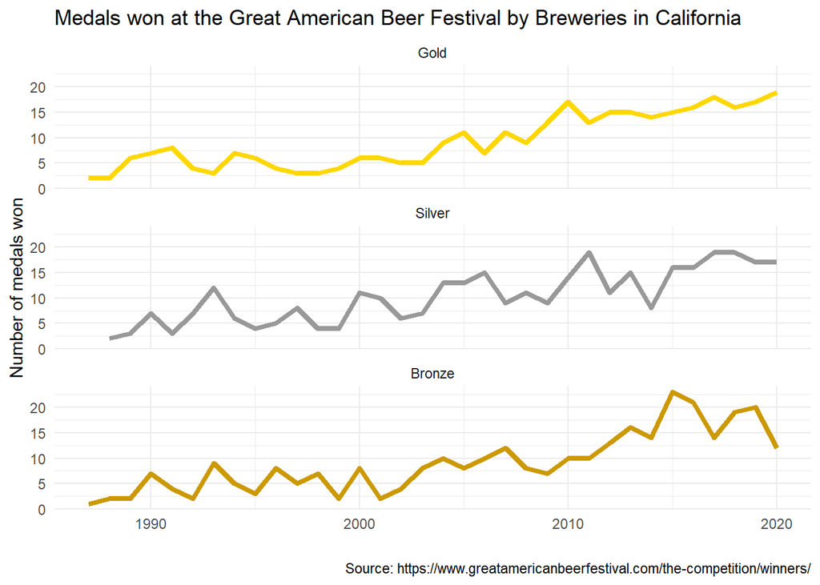

```r
plot_medals_by_year <- function(df, title, caption){
  gsb_colours <- c("gold", "#999999", "#CC9900")
  medal_levels_ordered <- c("Gold", "Silver", "Bronze")

  df %>%
    group_by(year, medal) %>%
    summarise(wins = n()) %>%
    ungroup () %>%

    ggplot(mapping = (aes(x = year, y = wins,
                          colour = factor(medal, level = medal_levels_ordered)
                          )
                      )
           ) +
    geom_line(size = 1.5) +

    scale_color_manual(values = gsb_colours) +

    guides(colour = FALSE) +

    facet_wrap(~factor(medal, level = medal_levels_ordered), ncol = 1) +

    labs(title = title, caption = caption,
         x = "",
         y = "Number of medals won") +

    theme_minimal()
}

p_title = "Medals won at the Great American Beer Festival by Breweries in California"
p_caption = "Source: https://www.greatamericanbeerfestival.com/the-competition/winners/"
p <- plot_medals_by_year(df = CA_awards, title = p_title, caption = p_caption)
p
```

```r
ggsave(filename = "California_wins_at_GABF.png")
```

```r
# gsb_colours <- c("gold", "#999999", "#CC9900")
# medal_levels_ordered <- c("Gold", "Silver", "Bronze")
#
# CA_awards %>%
#   group_by(year, medal) %>%
#   summarise(wins = n()) %>%
#   ungroup () %>%
#
#   ggplot(mapping = (aes(x = year, y = wins,
#                         colour = factor(medal, level = medal_levels_ordered)
#                         )
#                     )
#          ) +
#   geom_line(size = 1.5) +
#
#   scale_color_manual(values = gsb_colours) +
#
#   guides(colour = FALSE) +
#
#   facet_wrap(~factor(medal, level = medal_levels_ordered), ncol = 1) +
#
#   theme_minimal()
```

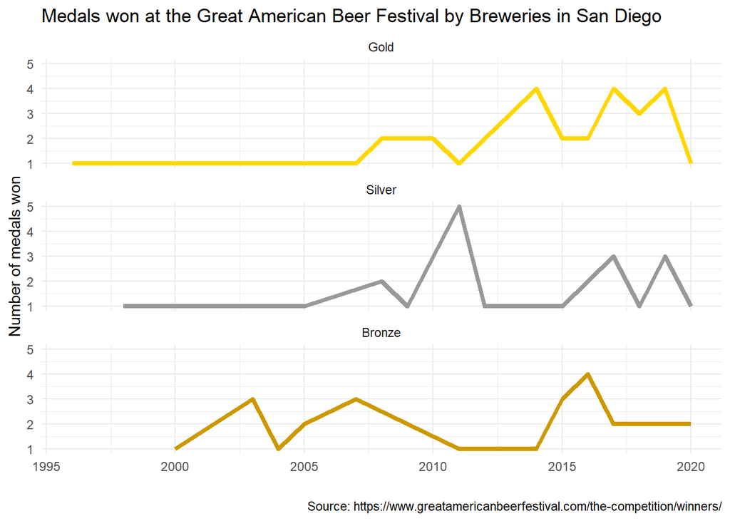

```r
p_title = "Medals won at the Great American Beer Festival by Breweries in San Diego"
p_caption = "Source: https://www.greatamericanbeerfestival.com/the-competition/winners/"
plot_medals_by_year(df = SD_awards, title = p_title, caption = p_caption)
```